# Testing

Group 2

## **DATA COLLECTION**

```r
set.seed(12)

data <- read.csv("../Video_Games_Sales_as_at_22_Dec_2016.csv",sep=",",na.strings=c(""," ","NA","N/A"))

data_row_count <- nrow(data)
```

#### Number of rows = **16719**

```r
# Show data
#head(data)
datatable(data[1:6,],
          options = list(scrollX = TRUE, pageLength = 6),
          rownames = FALSE)
```

| Name | Platform | Year_of_Release | Genre | Publisher | NA_Sales | EU_Sales | JP_Sales | Other_Sales | Global_Sales | Critic_Score | Critic_Count | User_Score | User_Count | Developer | Rating |
| --- | --- | --- | --- | --- | --- | --- | --- | --- | --- | --- | --- | --- | --- | --- | --- |
| Wii Sports | Wii | 2006 | Sports | Nintendo | 41.36 | 28.96 | 3.77 | 8.45 | 82.53 | 76 | 51 | 8 | 322 | Nintendo | E |
| Super Mario Bros. | NES | 1985 | Platform | Nintendo | 29.08 | 3.58 | 6.81 | 0.77 | 40.24 |  |  |  |  |  |  |
| Mario Kart Wii | Wii | 2008 | Racing | Nintendo | 15.68 | 12.76 | 3.79 | 3.29 | 35.52 | 82 | 73 | 8.3 | 709 | Nintendo | E |
| Wii Sports Resort | Wii | 2009 | Sports | Nintendo | 15.61 | 10.93 | 3.28 | 2.95 | 32.77 | 80 | 73 | 8 | 192 | Nintendo | E |
| Pokemon Red/Pokemon Blue | GB | 1996 | Role-Playing | Nintendo | 11.27 | 8.89 | 10.22 | 1 | 31.37 |  |  |  |  |  |  |
| Tetris | GB | 1989 | Puzzle | Nintendo | 23.2 | 2.26 | 4.22 | 0.58 | 30.26 |  |  |  |  |  |  |

```r
# Data cleaning
data <- na.omit(data)

na_row_count = data_row_count - nrow(data)
```

#### Number of rows with missing values = **9894**

#### New number of rows = **6825**

```r
# Show data after dropping all NA values
#head(data)
datatable(data[1:6,],
          options = list(scrollX = TRUE, pageLength = 6),
          rownames = FALSE)
```

| Name | Platform | Year_of_Release | Genre | Publisher | NA_Sales | EU_Sales | JP_Sales | Other_Sales | Global_Sales | Critic_Score | Critic_Count | User_Score | User_Count | Developer | Rating |
| --- | --- | --- | --- | --- | --- | --- | --- | --- | --- | --- | --- | --- | --- | --- | --- |
| Wii Sports | Wii | 2006 | Sports | Nintendo | 41.36 | 28.96 | 3.77 | 8.45 | 82.53 | 76 | 51 | 8 | 322 | Nintendo | E |
| Mario Kart Wii | Wii | 2008 | Racing | Nintendo | 15.68 | 12.76 | 3.79 | 3.29 | 35.52 | 82 | 73 | 8.3 | 709 | Nintendo | E |
| Wii Sports Resort | Wii | 2009 | Sports | Nintendo | 15.61 | 10.93 | 3.28 | 2.95 | 32.77 | 80 | 73 | 8 | 192 | Nintendo | E |
| New Super Mario Bros. | DS | 2006 | Platform | Nintendo | 11.28 | 9.14 | 6.5 | 2.88 | 29.8 | 89 | 65 | 8.5 | 431 | Nintendo | E |
| Wii Play | Wii | 2006 | Misc | Nintendo | 13.96 | 9.18 | 2.93 | 2.84 | 28.92 | 58 | 41 | 6.6 | 129 | Nintendo | E |
| New Super Mario Bros. Wii | Wii | 2009 | Platform | Nintendo | 14.44 | 6.94 | 4.7 | 2.24 | 28.32 | 87 | 80 | 8.4 | 594 | Nintendo | E |

```r
str(data)
```

```
## 'data.frame':    6825 obs. of  16 variables:
##  $ Name           : chr  "Wii Sports" "Mario Kart Wii" "Wii Sports Resort" "New Super Mario Bros." ...
##  $ Platform       : chr  "Wii" "Wii" "Wii" "DS" ...
##  $ Year_of_Release: int  2006 2008 2009 2006 2006 2009 2005 2007 2010 2009 ...
##  $ Genre          : chr  "Sports" "Racing" "Sports" "Platform" ...
##  $ Publisher      : chr  "Nintendo" "Nintendo" "Nintendo" "Nintendo" ...
##  $ NA_Sales       : num  41.4 15.7 15.6 11.3 14 ...
##  $ EU_Sales       : num  28.96 12.76 10.93 9.14 9.18 ...
##  $ JP_Sales       : num  3.77 3.79 3.28 6.5 2.93 4.7 4.13 3.6 0.24 2.53 ...
##  $ Other_Sales    : num  8.45 3.29 2.95 2.88 2.84 2.24 1.9 2.15 1.69 1.77 ...
##  $ Global_Sales   : num  82.5 35.5 32.8 29.8 28.9 ...
##  $ Critic_Score   : int  76 82 80 89 58 87 91 80 61 80 ...
##  $ Critic_Count   : int  51 73 73 65 41 80 64 63 45 33 ...
##  $ User_Score     : chr  "8" "8.3" "8" "8.5" ...
##  $ User_Count     : int  322 709 192 431 129 594 464 146 106 52 ...
##  $ Developer      : chr  "Nintendo" "Nintendo" "Nintendo" "Nintendo" ...
##  $ Rating         : chr  "E" "E" "E" "E" ...
##  - attr(*, "na.action")= 'omit' Named int [1:9894] 2 5 6 10 11 13 19 21 22 23 ...
##   ..- attr(*, "names")= chr [1:9894] "2" "5" "6" "10" ...
```

```r
# Drop all sales except global
data_df <- cbind(data[,-c(6:10)],data$Global_Sales)
data_df$Year_of_Release <- 2016 - data_df$Year_of_Release
names(data_df)[3] <- "Game_Age"
names(data_df)[12] <- "Global_Sales"

#name column is an id column we can remove for good (only used for games Top ten sales)
data_df <- data_df[,-1]

str(data_df)
```

```
## 'data.frame':    6825 obs. of  11 variables:
##  $ Platform    : chr  "Wii" "Wii" "Wii" "DS" ...
##  $ Game_Age    : num  10 8 7 10 10 7 11 9 6 7 ...
##  $ Genre       : chr  "Sports" "Racing" "Sports" "Platform" ...
##  $ Publisher   : chr  "Nintendo" "Nintendo" "Nintendo" "Nintendo" ...
##  $ Critic_Score: int  76 82 80 89 58 87 91 80 61 80 ...
##  $ Critic_Count: int  51 73 73 65 41 80 64 63 45 33 ...
##  $ User_Score  : chr  "8" "8.3" "8" "8.5" ...
##  $ User_Count  : int  322 709 192 431 129 594 464 146 106 52 ...
##  $ Developer   : chr  "Nintendo" "Nintendo" "Nintendo" "Nintendo" ...
##  $ Rating      : chr  "E" "E" "E" "E" ...
##  $ Global_Sales: num  82.5 35.5 32.8 29.8 28.9 ...
```

```r
summary(data_df)
```

```
##    Platform            Game_Age         Genre            Publisher
##  Length:6825        Min.   : 0.000   Length:6825        Length:6825
##  Class :character   1st Qu.: 5.000   Class :character   Class :character
##  Mode  :character   Median : 9.000   Mode  :character   Mode  :character
##                     Mean   : 8.563
##                     3rd Qu.:12.000
##                     Max.   :31.000
##   Critic_Score    Critic_Count     User_Score          User_Count
##  Min.   :13.00   Min.   :  3.00   Length:6825        Min.   :    4.0
##  1st Qu.:62.00   1st Qu.: 14.00   Class :character   1st Qu.:   11.0
##  Median :72.00   Median : 25.00   Mode  :character   Median :   27.0
##  Mean   :70.27   Mean   : 28.93                      Mean   :  174.7
##  3rd Qu.:80.00   3rd Qu.: 39.00                      3rd Qu.:   89.0
##  Max.   :98.00   Max.   :113.00                      Max.   :10665.0
##   Developer            Rating           Global_Sales
##  Length:6825        Length:6825        Min.   : 0.0100
##  Class :character   Class :character   1st Qu.: 0.1100
##  Mode  :character   Mode  :character   Median : 0.2900
##                                        Mean   : 0.7776
##                                        3rd Qu.: 0.7500
##                                        Max.   :82.5300
```

## **REGRESSION MODEL**

```r
reg_model <- data_df
str(reg_model)
```

```
## 'data.frame':    6825 obs. of  11 variables:
##  $ Platform    : chr  "Wii" "Wii" "Wii" "DS" ...
##  $ Game_Age    : num  10 8 7 10 10 7 11 9 6 7 ...
##  $ Genre       : chr  "Sports" "Racing" "Sports" "Platform" ...
##  $ Publisher   : chr  "Nintendo" "Nintendo" "Nintendo" "Nintendo" ...
##  $ Critic_Score: int  76 82 80 89 58 87 91 80 61 80 ...
##  $ Critic_Count: int  51 73 73 65 41 80 64 63 45 33 ...
##  $ User_Score  : chr  "8" "8.3" "8" "8.5" ...
##  $ User_Count  : int  322 709 192 431 129 594 464 146 106 52 ...
##  $ Developer   : chr  "Nintendo" "Nintendo" "Nintendo" "Nintendo" ...
##  $ Rating      : chr  "E" "E" "E" "E" ...
##  $ Global_Sales: num  82.5 35.5 32.8 29.8 28.9 ...
```

```r
# 70 : 30 RATIO
train.size <- floor(0.7*nrow(reg_model))
train.index <- sample(1:nrow(reg_model),train.size, replace = F)
train.set <- reg_model[train.index,]
test.set <- reg_model[-train.index,]
```

Train Size: **4777**

Test Size: **2048**

Total Size: **6825**

```r
model <- lm(formula = Global_Sales ~ Platform + Game_Age + Genre + Critic_Score + Critic_Count + User_Count + Rating, data = train.set)
summary(model)
```

```
##
## Call:
## lm(formula = Global_Sales ~ Platform + Game_Age + Genre + Critic_Score +
##     Critic_Count + User_Count + Rating, data = train.set)
##
## Residuals:
##    Min     1Q Median     3Q    Max
## -7.215 -0.576 -0.175  0.258 79.958
##
## Coefficients:
##                     Estimate Std. Error t value Pr(>|t|)
## (Intercept)       -1.171e+00  2.346e-01  -4.992 6.19e-07 ***
## PlatformDC        -6.450e-01  6.882e-01  -0.937 0.348738
## PlatformDS         2.236e-01  2.136e-01   1.047 0.295299
## PlatformGBA       -1.765e-01  2.564e-01  -0.688 0.491251
## PlatformGC        -3.370e-01  2.424e-01  -1.390 0.164486
## PlatformPC        -9.295e-01  2.084e-01  -4.459 8.42e-06 ***
## PlatformPS         4.418e-01  2.997e-01   1.474 0.140419
## PlatformPS2        2.428e-02  2.193e-01   0.111 0.911845
## PlatformPS3        4.770e-02  1.977e-01   0.241 0.809319
## PlatformPS4       -1.779e-01  2.293e-01  -0.776 0.438053
## PlatformPSP       -1.518e-01  2.189e-01  -0.693 0.488073
## PlatformPSV       -2.599e-01  2.735e-01  -0.950 0.342050
## PlatformWii        7.087e-01  2.097e-01   3.379 0.000732 ***
## PlatformWiiU      -1.050e-01  2.823e-01  -0.372 0.709918
## PlatformX360      -7.026e-02  1.978e-01  -0.355 0.722373
## PlatformXB        -5.523e-01  2.304e-01  -2.397 0.016578 *
## PlatformXOne       9.745e-02  2.505e-01   0.389 0.697260
## Game_Age           3.283e-02  1.234e-02   2.661 0.007816 **
## GenreAdventure    -2.265e-01  1.467e-01  -1.544 0.122744
## GenreFighting      6.289e-03  1.287e-01   0.049 0.961026
## GenreMisc          2.089e-01  1.293e-01   1.615 0.106286
## GenrePlatform     -1.540e-03  1.301e-01  -0.012 0.990555
## GenrePuzzle       -3.626e-01  2.096e-01  -1.730 0.083673 .
## GenreRacing       -6.588e-02  1.143e-01  -0.576 0.564553
## GenreRole-Playing -3.083e-01  1.008e-01  -3.058 0.002241 **
## GenreShooter      -2.826e-02  9.481e-02  -0.298 0.765693
## GenreSimulation    1.729e-01  1.419e-01   1.219 0.223016
## GenreSports        3.156e-02  1.085e-01   0.291 0.771176
## GenreStrategy     -3.224e-01  1.507e-01  -2.139 0.032463 *
## Critic_Score       1.872e-02  2.254e-03   8.306  < 2e-16 ***
## Critic_Count       1.972e-02  1.830e-03  10.779  < 2e-16 ***
## User_Count         7.639e-04  5.254e-05  14.541  < 2e-16 ***
## RatingE10+        -2.624e-01  9.512e-02  -2.758 0.005836 **
## RatingK-A         -2.707e-01  1.829e+00  -0.148 0.882338
## RatingM           -3.200e-01  1.055e-01  -3.033 0.002431 **
## RatingT           -3.437e-01  8.440e-02  -4.072 4.74e-05 ***
## ---
## Signif. codes:  0 '***' 0.001 '**' 0.01 '*' 0.05 '.' 0.1 ' ' 1
##
## Residual standard error: 1.816 on 4741 degrees of freedom
## Multiple R-squared:  0.1724, Adjusted R-squared:  0.1663
## F-statistic: 28.22 on 35 and 4741 DF,  p-value: < 2.2e-16
```

```r
model$coefficients
```

```
##       (Intercept)        PlatformDC        PlatformDS       PlatformGBA
##     -1.1712803289     -0.6449630694      0.2236190083     -0.1764695724
##        PlatformGC        PlatformPC        PlatformPS       PlatformPS2
##     -0.3369933140     -0.9294689556      0.4418297356      0.0242802991
##       PlatformPS3       PlatformPS4       PlatformPSP       PlatformPSV
##      0.0477049022     -0.1778682405     -0.1517710693     -0.2598773792
##       PlatformWii      PlatformWiiU      PlatformX360        PlatformXB
##      0.7087498526     -0.1050272685     -0.0702638689     -0.5522826466
##      PlatformXOne          Game_Age    GenreAdventure     GenreFighting
##      0.0974464592      0.0328302207     -0.2264610167      0.0062892079
##         GenreMisc     GenrePlatform       GenrePuzzle       GenreRacing
##      0.2088792572     -0.0015399900     -0.3625862756     -0.0658802328
## GenreRole-Playing      GenreShooter   GenreSimulation       GenreSports
##     -0.3082597584     -0.0282564525      0.1729248306      0.0315619588
##     GenreStrategy      Critic_Score      Critic_Count        User_Count
##     -0.3224492858      0.0187194182      0.0197234646      0.0007639422
##        RatingE10+         RatingK-A           RatingM           RatingT
##     -0.2623657092     -0.2707407423     -0.3199581240     -0.3436932127
```

## **OUTLIERS, LEVERAGE AND INFLUENTIAL POINTS**

```r
which(hatvalues(model) > 0.08)
```

```
##  3816  9846  8906 11000  5351  1713  7979  7232   904
##   660   770  1354  1469  1782  2013  3723  4179  4196
```

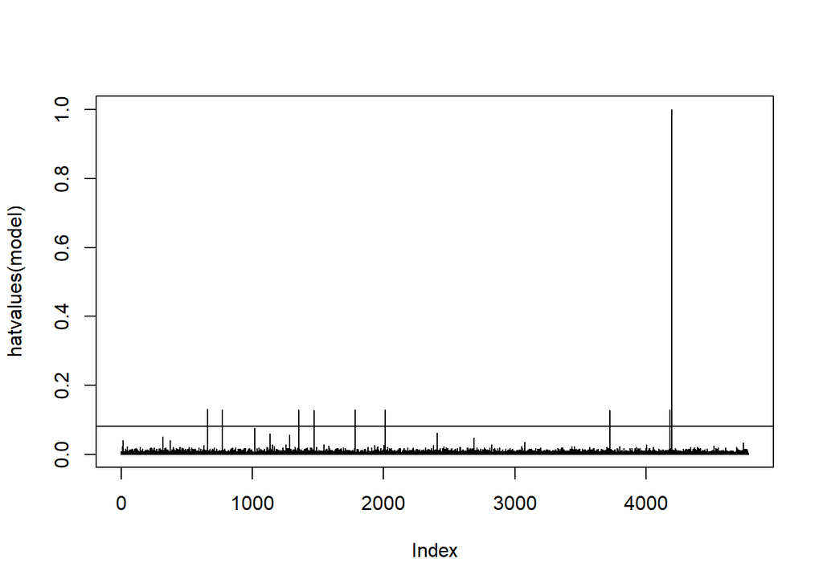

```r
plot(hatvalues(model),type="h"); abline(h=0.08)
```

```r
which(cooks.distance(model)>1)
```

```
## named integer(0)
```

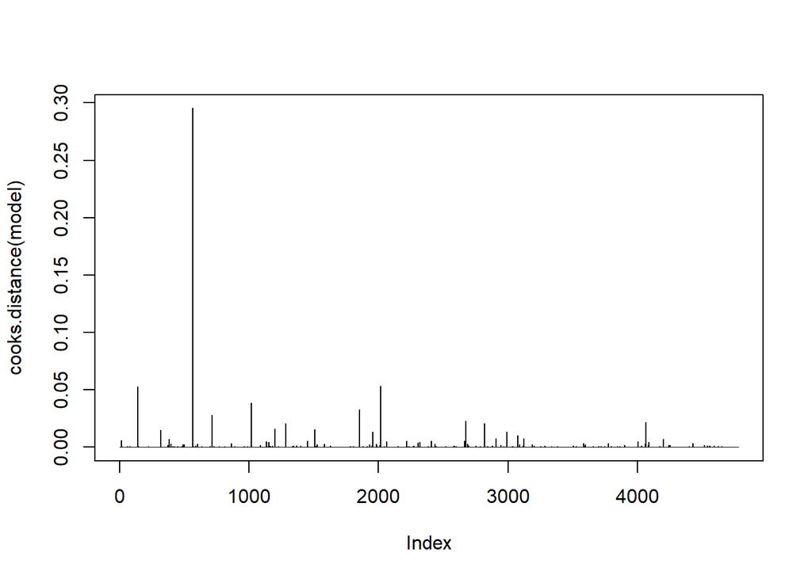

```r
plot(cooks.distance(model),type="h"); abline(h=1)
```

## **DIAGNOSTIC CHECKING**

### **I. NORMALITY**

#### **1. Graphical Analysis of Residuals**

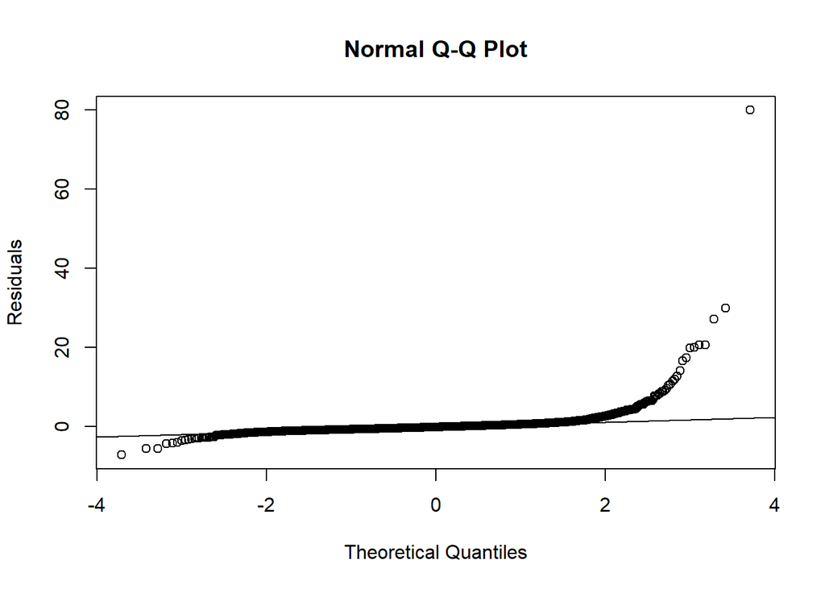

```r
qqnorm(residuals(model), ylab="Residuals")
qqline(residuals(model)) # Normality using Q-Q Plots
```

#### **2. Statistical Test**

**Ho**: ϵ’s normally distributed.

**Ha**: ϵ’s not normally distributed.

##### **2.1. Kolmogorov-Smirnov Test**

```r
resid_std <- scale(residuals(model)) # mean=0, sd=1
ks_test <- ks.test(resid_std, "pnorm") # Kolmogorov-Smirnov Test
ks_test
```

```
##
##  Asymptotic one-sample Kolmogorov-Smirnov test
##
## data:  resid_std
## D = 0.23841, p-value < 2.2e-16
## alternative hypothesis: two-sided
```

We reject the null hypothesis, therefore, **the residuals are not normally distributed.**

### **II. HOMOSCEDASTICITY**

#### **1. Graphical Analysis of Residuals**

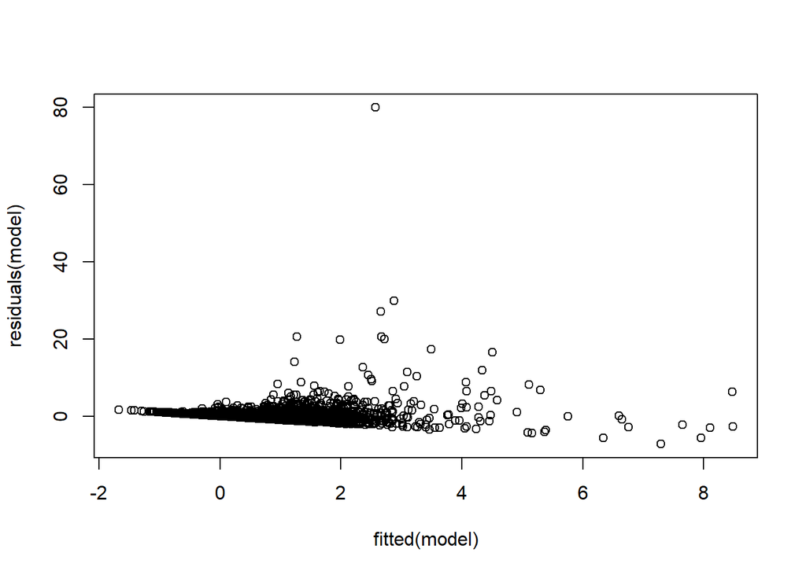

```r
plot(fitted(model), residuals(model))
```

#### **2. Statistical Test**

**Ho**: Heteroscedasticity is not present.

**Ha**: Heteroscedasticity is present.

##### **2.1. Breusch-Pagan-Godfrey Test**

```r
bp_test <- bptest(model) # Breusch-Pagan test
bp_test
```

```
##
##  studentized Breusch-Pagan test
##
## data:  model
## BP = 49.42, df = 35, p-value = 0.05385
```

We fail to reject the null hypothesis, therefore, **Heteroscedasticity is not present.**

### **III. MULTICOLINEARITY**

#### **1. Statistical Test**

```r
vif_values = vif(model)
vif_values
```

```
##                  GVIF Df GVIF^(1/(2*Df))
## Platform     8.604144 16        1.069571
## Game_Age     4.004819  1        2.001205
## Genre        3.160743 11        1.053702
## Critic_Score 1.394692  1        1.180971
## Critic_Count 1.787691  1        1.337046
## User_Count   1.398630  1        1.182637
## Rating       2.881253  4        1.141426
```

VIF > 5 -> **moderate concern**

VIF > 10 -> **serious multicollinearity**

```
## [1] "Platform is okay (VIF = 1.07 )"
## [1] "Game_Age is okay (VIF = 2 )"
## [1] "Genre is okay (VIF = 1.05 )"
## [1] "Critic_Score is okay (VIF = 1.18 )"
## [1] "Critic_Count is okay (VIF = 1.34 )"
## [1] "User_Count is okay (VIF = 1.18 )"
## [1] "Rating is okay (VIF = 1.14 )"
```

### **IV. INDEPENDENCE**

#### **1. Graphical Analysis of Residuals**

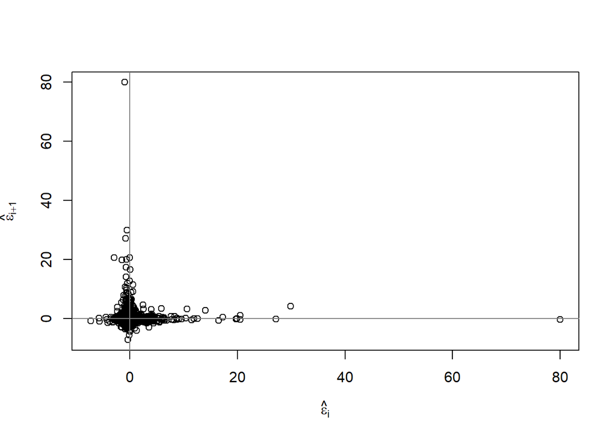

```r
n = length(residuals(model))
plot(tail(residuals(model), n-1) ~
head(residuals(model), n-1),
xlab=expression(hat(epsilon)[i]),
ylab=expression(hat(epsilon)[i+1]))
abline(h=0, v=0, col = grey(0.5))
```

#### **2. Statistical Test**

**Ho**: No auto-correlation (the errors are uncorrelated)

**Ha**: There exists auto-correlation

##### **2.1. Durbin-Watson Test**

```r
dw_test = dwtest(model) # Durbin-Watson Test
dw_test
```

```
##
##  Durbin-Watson test
##
## data:  model
## DW = 2.0046, p-value = 0.5629
## alternative hypothesis: true autocorrelation is greater than 0
```

We fail to reject the null hypothesis, therefore, **there is no auto-correlation.**

## **DATA TRANSFORMATION (Logarithmic Model)**

Since the model is not normally distributed based on the results of the Kolmogorov-Smirnov test, we perform a data transformation using the **Logarithmic Model**.

```r
train.set$Log_Global_Sales <- log(train.set$Global_Sales)

model_log <- lm(Log_Global_Sales ~ Platform + Game_Age + Genre +
                Critic_Score + Critic_Count + User_Count + Rating,
                data = train.set)

summary(model_log)
```

```
##
## Call:
## lm(formula = Log_Global_Sales ~ Platform + Game_Age + Genre +
##     Critic_Score + Critic_Count + User_Count + Rating, data = train.set)
##
## Residuals:
##     Min      1Q  Median      3Q     Max
## -4.3469 -0.6630  0.0164  0.6905  4.1062
##
## Coefficients:
##                     Estimate Std. Error t value Pr(>|t|)
## (Intercept)       -3.442e+00  1.356e-01 -25.384  < 2e-16 ***
## PlatformDC        -3.526e-01  3.977e-01  -0.886 0.375433
## PlatformDS         1.131e-02  1.235e-01   0.092 0.927029
## PlatformGBA       -1.452e-01  1.481e-01  -0.980 0.327244
## PlatformGC        -2.461e-01  1.401e-01  -1.757 0.078935 .
## PlatformPC        -1.686e+00  1.205e-01 -13.997  < 2e-16 ***
## PlatformPS         8.049e-01  1.732e-01   4.648 3.44e-06 ***
## PlatformPS2        2.463e-01  1.267e-01   1.943 0.052018 .
## PlatformPS3        2.214e-01  1.142e-01   1.938 0.052684 .
## PlatformPS4       -4.702e-01  1.325e-01  -3.548 0.000392 ***
## PlatformPSP       -1.111e-01  1.265e-01  -0.878 0.379776
## PlatformPSV       -5.473e-01  1.580e-01  -3.463 0.000539 ***
## PlatformWii        4.393e-01  1.212e-01   3.625 0.000292 ***
## PlatformWiiU      -2.893e-01  1.632e-01  -1.773 0.076278 .
## PlatformX360      -4.340e-02  1.143e-01  -0.380 0.704125
## PlatformXB        -5.758e-01  1.332e-01  -4.324 1.56e-05 ***
## PlatformXOne      -7.414e-02  1.447e-01  -0.512 0.608525
## Game_Age           5.490e-03  7.130e-03   0.770 0.441306
## GenreAdventure    -5.086e-01  8.478e-02  -5.999 2.13e-09 ***
## GenreFighting      3.638e-02  7.437e-02   0.489 0.624786
## GenreMisc          2.579e-01  7.472e-02   3.452 0.000562 ***
## GenrePlatform     -1.460e-02  7.517e-02  -0.194 0.846050
## GenrePuzzle       -6.680e-01  1.211e-01  -5.515 3.66e-08 ***
## GenreRacing       -1.855e-01  6.608e-02  -2.807 0.005027 **
## GenreRole-Playing -2.684e-01  5.826e-02  -4.607 4.19e-06 ***
## GenreShooter      -4.200e-02  5.479e-02  -0.766 0.443424
## GenreSimulation    3.537e-01  8.200e-02   4.313 1.64e-05 ***
## GenreSports       -2.641e-02  6.271e-02  -0.421 0.673669
## GenreStrategy     -5.004e-01  8.710e-02  -5.745 9.76e-09 ***
## Critic_Score       2.654e-02  1.302e-03  20.378  < 2e-16 ***
## Critic_Count       2.187e-02  1.057e-03  20.679  < 2e-16 ***
## User_Count         4.620e-04  3.036e-05  15.218  < 2e-16 ***
## RatingE10+        -1.376e-01  5.497e-02  -2.504 0.012329 *
## RatingK-A          1.297e-01  1.057e+00   0.123 0.902327
## RatingM           -2.974e-01  6.095e-02  -4.880 1.10e-06 ***
## RatingT           -3.204e-01  4.878e-02  -6.569 5.60e-11 ***
## ---
## Signif. codes:  0 '***' 0.001 '**' 0.01 '*' 0.05 '.' 0.1 ' ' 1
##
## Residual standard error: 1.05 on 4741 degrees of freedom
## Multiple R-squared:  0.4345, Adjusted R-squared:  0.4303
## F-statistic: 104.1 on 35 and 4741 DF,  p-value: < 2.2e-16
```

## **DIAGNOSTIC CHECKING AFTER DATA TRANSFORMATION**

### **I. NORMALITY**

#### **1. Graphical Analysis of Residuals**

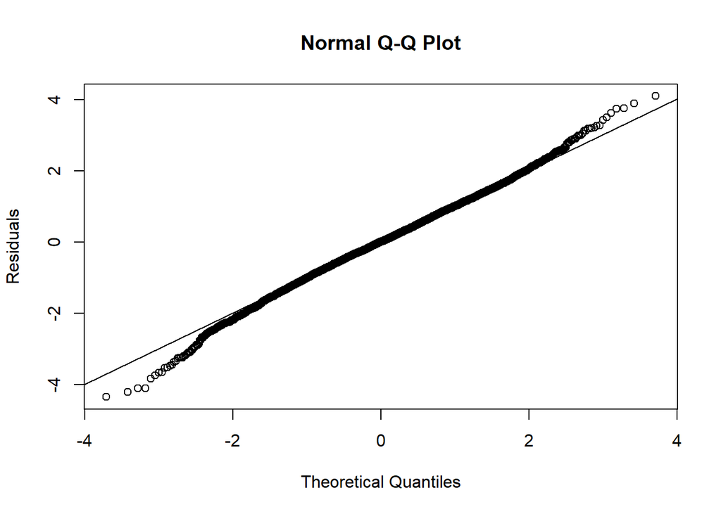

```r
qqnorm(residuals(model_log), ylab="Residuals")
qqline(residuals(model_log)) # Normality using Q-Q Plots
```

#### **2. Statistical Test**

**Ho**: ϵ’s normally distributed.

**Ha**: ϵ’s not normally distributed.

##### **2.1. Kolmogorov-Smirnov Test**

```r
resid_std <- scale(residuals(model_log)) # mean=0, sd=1
ks_test <- ks.test(resid_std, "pnorm") # Kolmogorov-Smirnov Test
ks_test
```

```
##
##  Asymptotic one-sample Kolmogorov-Smirnov test
##
## data:  resid_std
## D = 0.018272, p-value = 0.08236
## alternative hypothesis: two-sided
```

We fail to reject the null hypothesis, therefore, **the residuals are normally distributed.**

### **II. HOMOSCEDASTICITY**

#### **1. Graphical Analysis of Residuals**

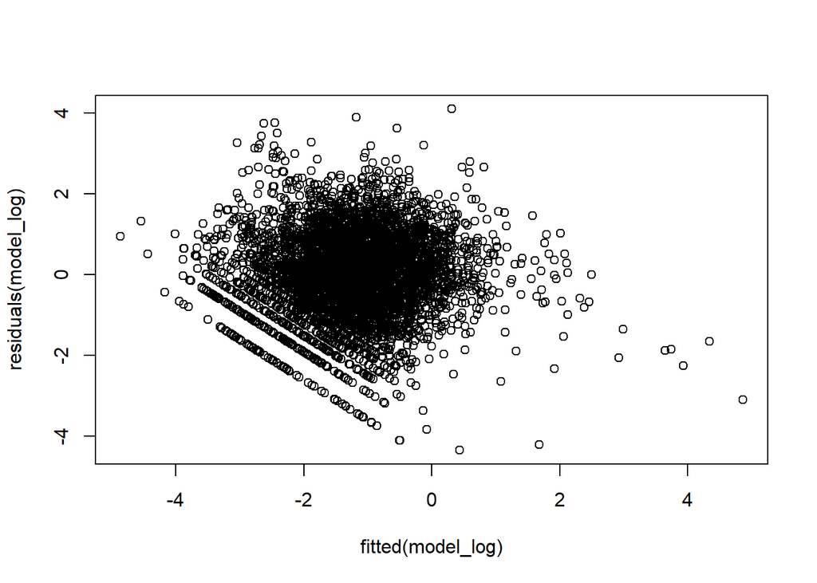

```r
plot(fitted(model_log), residuals(model_log))
```

#### **2. Statistical Test**

**Ho**: Heteroscedasticity is not present.

**Ha**: Heteroscedasticity is present.

##### **2.1. Breusch-Pagan-Godfrey Test**

```r
bp_test <- bptest(model_log) # Breusch-Pagan test
bp_test
```

```
##
##  studentized Breusch-Pagan test
##
## data:  model_log
## BP = 295.26, df = 35, p-value < 2.2e-16
```

We reject the null hypothesis, therefore, **Heteroscedasticity is present.**

### **III. MULTICOLINEARITY**

#### **1. Statistical Test**

```r
vif_values = vif(model_log)
vif_values
```

```
##                  GVIF Df GVIF^(1/(2*Df))
## Platform     8.604144 16        1.069571
## Game_Age     4.004819  1        2.001205
## Genre        3.160743 11        1.053702
## Critic_Score 1.394692  1        1.180971
## Critic_Count 1.787691  1        1.337046
## User_Count   1.398630  1        1.182637
## Rating       2.881253  4        1.141426
```

VIF > 5 -> **moderate concern**

VIF > 10 -> **serious multicollinearity**

```
## [1] "Platform is okay (VIF = 1.07 )"
## [1] "Game_Age is okay (VIF = 2 )"
## [1] "Genre is okay (VIF = 1.05 )"
## [1] "Critic_Score is okay (VIF = 1.18 )"
## [1] "Critic_Count is okay (VIF = 1.34 )"
## [1] "User_Count is okay (VIF = 1.18 )"
## [1] "Rating is okay (VIF = 1.14 )"
```

### **IV. INDEPENDENCE**

#### **1. Graphical Analysis of Residuals**

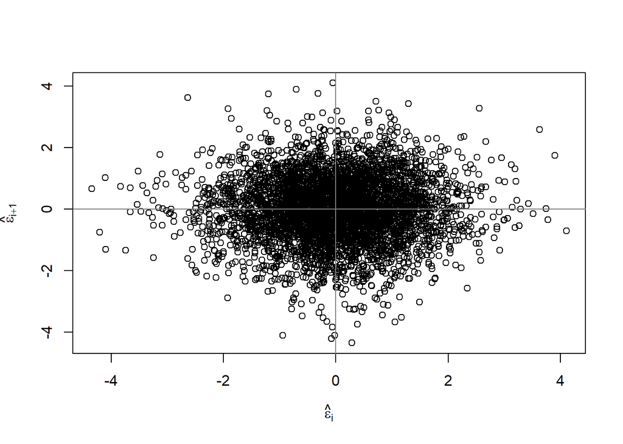

```r
n = length(residuals(model_log))
plot(tail(residuals(model_log), n-1) ~
head(residuals(model_log), n-1),
xlab=expression(hat(epsilon)[i]),
ylab=expression(hat(epsilon)[i+1]))
abline(h=0, v=0, col = grey(0.5))
```

#### **2. Statistical Test**

**Ho**: No auto-correlation (the errors are uncorrelated)

**Ha**: There exists auto-correlation

##### **2.1. Durbin-Watson Test**

```r
dw_test = dwtest(model_log) # Durbin-Watson Test
dw_test
```

```
##
##  Durbin-Watson test
##
## data:  model_log
## DW = 1.9757, p-value = 0.2
## alternative hypothesis: true autocorrelation is greater than 0
```

We fail to reject the null hypothesis, therefore, **there is no auto-correlation.**

## VARIABLE SELECTION

```r
k<-ols_step_best_subset(model_log)
k
```

```
##                              Best Subsets Regression
## ----------------------------------------------------------------------------------
## Model Index    Predictors
## ----------------------------------------------------------------------------------
##      1         Critic_Count
##      2         Platform Critic_Count
##      3         Platform Critic_Score Critic_Count
##      4         Platform Critic_Score Critic_Count User_Count
##      5         Platform Genre Critic_Score Critic_Count User_Count
##      6         Platform Genre Critic_Score Critic_Count User_Count Rating
##      7         Platform Game_Age Genre Critic_Score Critic_Count User_Count Rating
## ----------------------------------------------------------------------------------
##
##                                                        Subsets Regression Summary
## -----------------------------------------------------------------------------------------------------------------------------------------
##                        Adj.        Pred
## Model    R-Square    R-Square    R-Square      C(p)          AIC          SBIC          SBC          MSEP        FPE       HSP      APC
## -----------------------------------------------------------------------------------------------------------------------------------------
##   1        0.1760      0.1759      0.1754    2134.9867    15786.6076    2228.6446    15806.0223    7612.6404    1.5943    3e-04    0.8247
##   2        0.3082      0.3057       0.303    1059.1611    14983.6236    1395.9642    15106.5834    6393.1495    1.3434    3e-04    0.6927
##   3        0.3772      0.3748      0.3721     482.5588    14483.6101     896.3757    14613.0415    5756.5990    1.2099    3e-04    0.6239
##   4        0.4047      0.4024      0.3992     253.5887    14269.4886     682.5182    14405.3915    5503.1151    1.1568    2e-04    0.5965
##   5        0.4291      0.4255      0.4208      71.1682    14091.6965     485.1347    14298.7867    5278.8073    1.1123    2e-04    0.5723
##   6        0.4344      0.4304        -Inf      34.5930    14054.9982     442.5639    14287.9747    5230.7406    1.1031    2e-04    0.5672
##   7        0.4345      0.4303        -Inf      36.0000    14056.4008     443.9834    14295.8488    5231.1834    1.1034    2e-04    0.5674
## -----------------------------------------------------------------------------------------------------------------------------------------
## AIC: Akaike Information Criteria
##  SBIC: Sawa's Bayesian Information Criteria
##  SBC: Schwarz Bayesian Criteria
##  MSEP: Estimated error of prediction, assuming multivariate normality
##  FPE: Final Prediction Error
##  HSP: Hocking's Sp
##  APC: Amemiya Prediction Criteria
```

##### **Model 6** is the best model because despite it having a lesser R-Squared than Model 7, it still has the highest Adj. R-Square. It also has the lowest value of C(p), AIC, SBIC, and SBC.

## 3-FOLD CROSS VALIDATION

```r
# Define training control
train.control <- trainControl(method = "cv", number = 3)

model <- train(log(Global_Sales) ~ Platform + Game_Age + Genre + Critic_Score + Critic_Count + User_Count + Rating, data = data_df, method = "lm", trControl = train.control)

# Summarize the results
print(model)
```

```
## Linear Regression
##
## 6825 samples
##    7 predictor
##
## No pre-processing
## Resampling: Cross-Validated (3 fold)
## Summary of sample sizes: 4550, 4550, 4550
## Resampling results:
##
##   RMSE      Rsquared   MAE
##   1.049784  0.4375043  0.8227829
##
## Tuning parameter 'intercept' was held constant at a value of TRUE
```